# Gallardo_ADO_PEC1

Lorena Gallardo

1/5/2020

**Enlace al GitHub:**https://github.com/LorenaGaMo/Gallardo_ADO_PEC1.git

# ABSTRACT

# OBJETIVOS

El objetivo del estudio es estudiar las diferencias de expresión génica de la poda de axones dependiendo del estado de desarrollo en que se encuentra el díptero.

El objetivo de este trabajo es poner en práctica los conocimientos adquiridos para realizar un análisis de datos de microarray. Se trata de un estudio de un factor con tres niveles diferentes (prepupa, pupa, pupa de 5 horas) y el objetivo es seleccionar los genes que se estén expresando de manera diferencial según la edad del individuo.

# MATERIAL Y MÉTODOS

## Software y naturaleza de los datos

El software utilizado para realizar este estudio es el siguiente: R[^1] (versión 3.6.3) con el interfaz RStudio[^2] y los paquetes de Bioconductor Affy[^3] (versión 3.10). El paquete de R (‘limma()’) para el ajuste del modelo lineal y la selección de genes. Para el * Gene Enrichment Analysis* se ha utilizado la aplicación g:Profiler,[^4] debido a que con el paquete *ReactomePA* de R he tenido diversos problemas.

Este trabajo se basa en el artículo de Hoopfer ED (n.d.) y los datos públicos extraidos de de la base de datos Gene Expression Omnibus con su correspondiente códiga GSE10012.[^5]

## Preparación de los datos

Antes de empezar con el analisi propiamente se debe preparar el entorno de trabajo con un sistema de archivos.el hecho de tener la información bien estructurada facilita el proceso del analisis. Es recomendable tener instaladas las librerias necesarias ya que el proceso puede ser largo.

```r
> setwd(".")
> dir.create("data")
> dir.create("results")
> dir.create("figuras")
```

## Lectura datos crudos

Se debe preparar un fixero *targets.csv* de manera manual con la información obtenida en la base de datos (Table 1).

```r
> targets <- read.csv2("./data/targets.csv", header = TRUE, sep = ",")
> knitr::kable(
+   targets, booktabs = TRUE,
+   caption = 'Contenido del fichero *targets.csv* ')
```

Contenido del fichero *targets.csv*

| ï..FileName | Age | Grupo | ShortName |
| --- | --- | --- | --- |
| GSM252982 | Prepupa | Pre | Pre82 |
| GSM252983 | Prepupa | Pre | Pre83 |
| GSM252984 | Prepupa | Pre | Pre84 |
| GSM252985 | Prepupa | Pre | Pre85 |
| GSM252986 | Prepupa | Pre | Pre86 |
| GSM252987 | Prepupa | Pre | Pre87 |
| GSM252988 | Prepupa | Pre | Pre88 |
| GSM252989 | Pupa 0h | P0 | P0_89 |
| GSM252990 | Pupa 0h | P0 | P0_90 |
| GSM252991 | Pupa 0h | P0 | P0_91 |
| GSM252992 | Pupa 0h | P0 | P0_92 |
| GSM252993 | Pupa 0h | P0 | P0_93 |
| GSM252994 | Pupa 0h | P0 | P0_94 |
| GSM252995 | Pupa 0h | P0 | P0_95 |
| GSM252996 | Pupa 0h | P5 | P5_96 |
| GSM252997 | Pupa 0h | P5 | P5_97 |
| GSM252998 | Pupa 0h | P5 | P5_98 |

Para leer los ficheros *.CEL* propiamente se crea un nuevo data frame *rawData*, donde previamente de debe crar un nuevo objeto *my.targets* associado a los archivos *.CEL*.

## Control de calidad y exploración de los datos

Se realiza un control de calidad de los datos con el paquete ‘arrayQualityMetrics()’ el cual realiza diferentes test. El resumen del análisis de calidad lo encontramos dentro de la carpeta “resunts” en el fichero “index.htlm”(Figura 1). Las columnas 1, 2, y 3 nos indican los diferentes criterios de detección de *outlier* respectivamente: mediante distancias entre arrays, mediante boxplot y mediante MA plots. Podemos observar que en las columnas 1 y 3 tenemos señaladas diversas muestras con una “X”, esto nos indica que los posibles problemas a la ahora de normalizar los datos podrían derivarse de estas muestras ya que nos indica que esas muestras se pueden considerar que tienen *outliers* en su distibución, en la categoria de la casilla donde estan señaladas.

```r
> arrayQualityMetrics(rawData, outdir = file.path("./results","rawData_quality"), force = T)
```

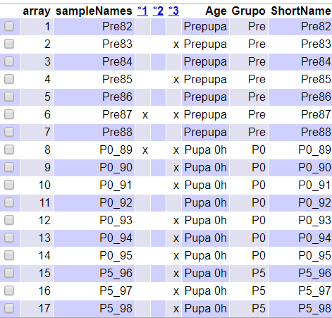

Fig.1 Tabla resumen de la calidad de los datos del fichero index.htlm

```r
> knitr::include_graphics("figuras/ResumQM.png")
```

El control de calidad de los datos crudos también se puede realizar con un análisis gráfico. Para este trabajo se han realizado un boxplot (Fig.2), un cluster (Fig.3) y un análisis de componentes principales (Fig.4).En el caso del análisis de las componentes principales se ha utilizado la función definida por Gonzalo Sanz and Sánchez-Pla (2019) y especificada en el apendice adjunto.

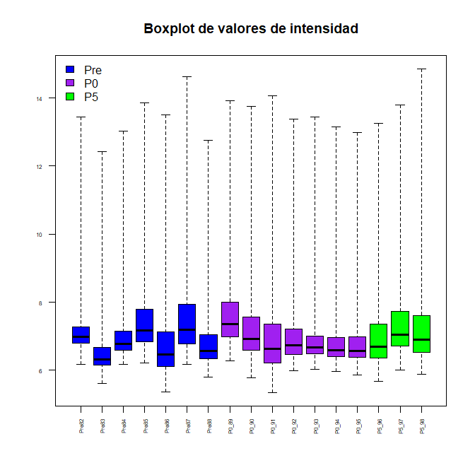

Boxplot de los datos crudos

En el boxplot podemos observar que la intensidad de las muestras es algo irregular tanto en el tamaño de las cajas como en su media. Tendremos que ver si al normalizar los datos se mejora esta variabilidad.

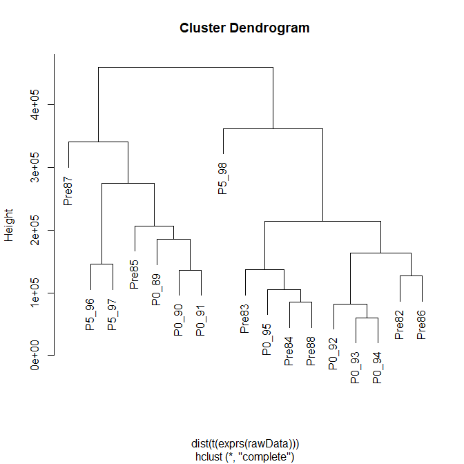

Cluster de los datos crudos

Con el cluster de los datos crudos podemos observar que no existe una jerarquía entre los diferentes grupos, todas las muestras están mezcladas. Como pasa con el boxplot miraremos de mejóralo con la normalización de los datos.

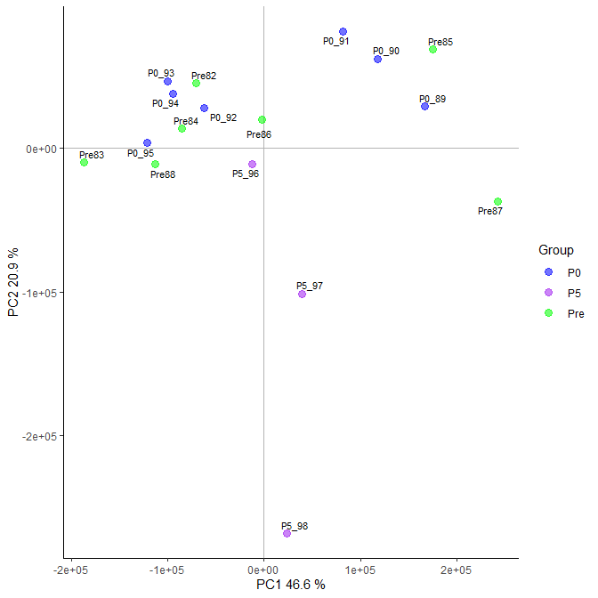

Anàlisis PCA de los datos crudos

En el gráfico de las componentes principales vemos que la primera componente se explica el 46.6% de la variabilidad y el 20.9% con la segunda componente. Pero no se observan grupos definidos i diferencias entre las muestras.

## Normalización

Con el paso de normalización de los datos pretendemos mejorar los análisis anteriores con el objetivo de poder comparar las diferentes muestras entre sí y eliminar la variabilidad, debida a los efectos de la técnica o el análisis y no a la producida por las diferencias biológicas, con la transformación de los datos. Se ha utilizado un método de normalización RMA, uno de los métodos más utilizados en la normalización de datos procedentes de array de Affymetrix, descrito por Irizarry (2003). Para la realización de esta se ha creado un nuevo objeto con la función ‘rma()’.

```
Background correcting
Normalizing
Calculating Expression
```

```
ExpressionSet (storageMode: lockedEnvironment)
assayData: 14010 features, 17 samples
  element names: exprs
protocolData
  rowNames: Pre82 Pre83 ...  P5_98 (17 total)
  varLabels: exprs dates
  varMetadata: labelDescription channel
phenoData
  rowNames: Pre82 Pre83 ...  P5_98 (17 total)
  varLabels: Age Grupo ShortName
  varMetadata: labelDescription channel
featureData: none
experimentData: use 'experimentData(object)'
Annotation: pd.drosgenome1
```

## Control de calidad y exploración datos normalizados

Se vuelve a realizar un control de calidad de los datos pero esta vez ya transformados. En los nevos resultados se puede observar una mejora considerable de los datos, la unica muestra que presenta problemas es la Pre82 cn dos *outliers*.

```r
> arrayQualityMetrics(eset_rma, outdir = file.path("./results", "rawDataNorm_quality"), force = T)
```

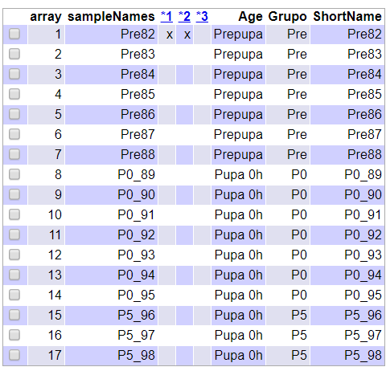

Tabla resumen análisa datos normalizazados

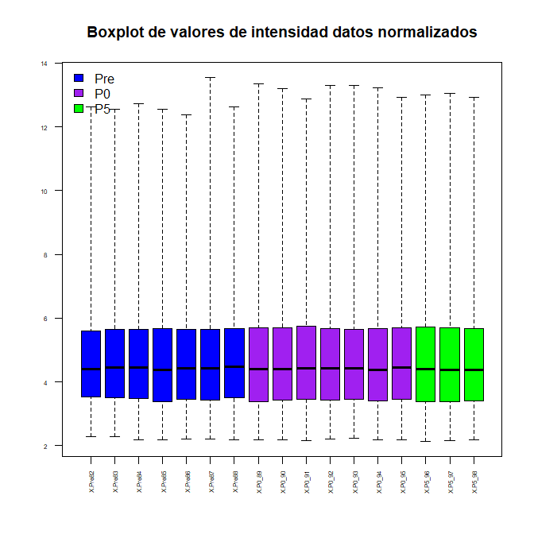

```r
> knitr::include_graphics("figuras/ResumQM_norm.png")
```

El boxplot corrobora lo que hemos visto con el análisis anterior. La intensidad de las muestras es mucho más regular tanto en el tamaño de las cajas como en su media, aunque se pueden apreciar pequeñas diferencias.

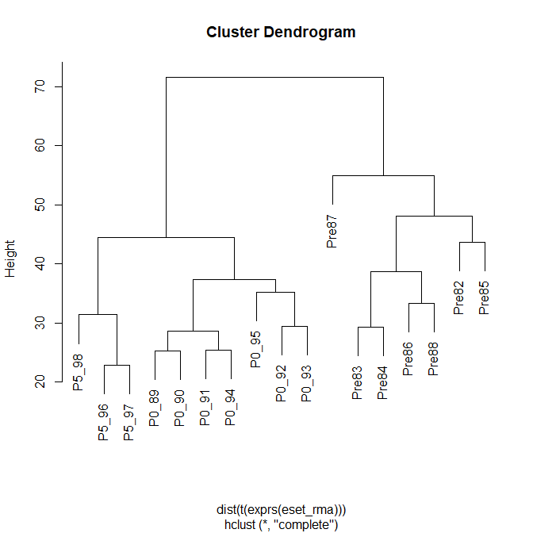

Cluster datos normalizados

Esta vez sí que podemos observar una jerarquía definida en el clúster de los datos normalizados. Se diferencian claramente las prepupas de las pupas y dentro del estas últimas se observa que las pupas de cero horas también de diferencian de las de 5 h.

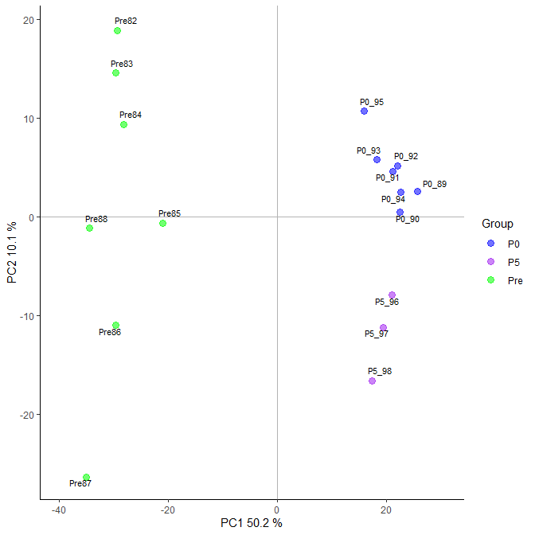

Anàlisis PCA de los datos normalizadoss

En análisis de componentes principales de los datos normalizados volvemos a ver los tres grupos definidos y diferenciados como lo podíamos ver en el clúster. Esta vez la variabilidad entre ellos esta explicada en un 50.2% por la primera componente y en un 10.1% por la segunda.

## Selección de genes

Para ver qué porcentaje de genes presentan una variabilidad superior a la variabilidad intrínseca entre muestras, ya que estos serían los genes que están expresados diferencialmente. Esto se puede observar gráficamente con la representación de la desviación estándar de todos los genes. Se puede apreciar que hay un gran número de genes que se están expresando diferencialmente, aunque no llega a ser el 5% de los genes. Los genes que se consideran con más variabilidad son aquellos con una desviación estándar por encima de los percentiles 90% y 95% , representados en el grafico por las líneas verticales.

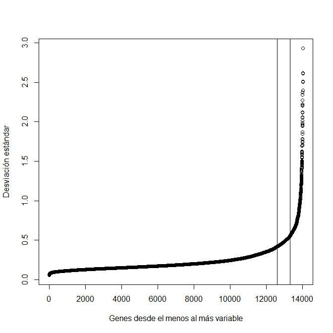

Distrubución de la variabilidad genica

## Anotaciones

Las anotaciones son el paso previo al filtraje de los datos normalizados para poder eliminar los genes sin identificador asociado. Para esto se debe cargar la librería *drosgenome1.db* para este estudio ( cada estudio tiene su paquete de anotaciones asociado) y así anidar el identificador del gen con la sonda.

```r
> library(drosgenome1.db)
> annotation(eset_rma)<-"drosgenome1.db"
```

## Filtraje de genes

```
$numDupsRemoved
[1] 1483

$numLowVar
[1] 8628

$numRemoved.ENTREZID
[1] 1023
```

## Control de calidad datos filtrados

Una vez filtrados los datos normalizados se vuelve a realizar un control de calidad de los datos como en las veces anteriores. Esta vez podemos comprobar que se ha vuelto a mejorar el resultado y la muestra que presentaba problemas de *outliers* ya no los presenta.

```r
> arrayQualityMetrics(eset_filt, outdir = file.path("./results", "Norm_data_filt"), force= T)
```

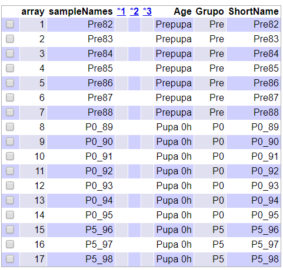

Resumen de la calidad de los datos filtrados

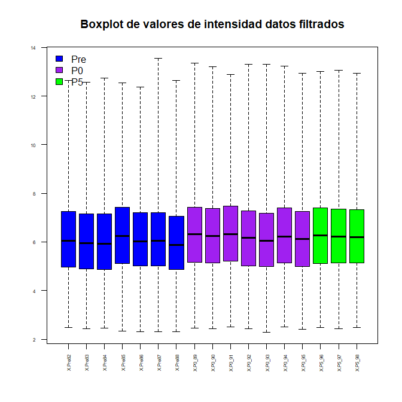

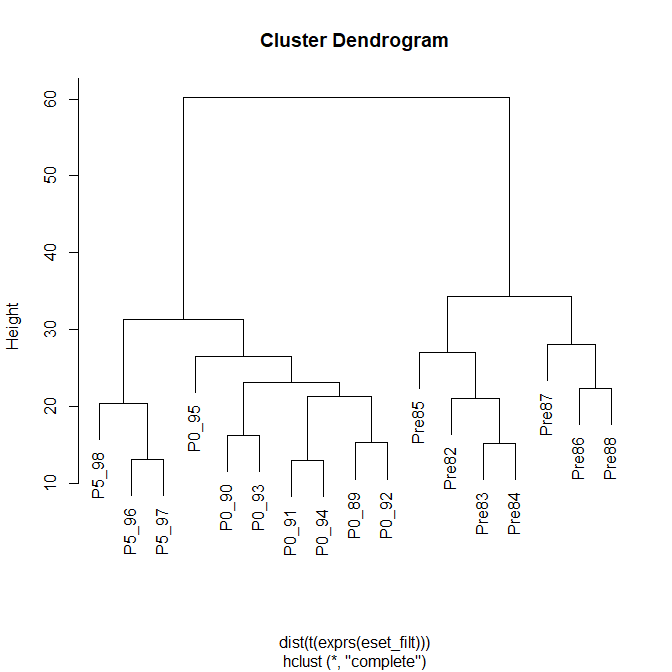

Cluster datos filtrados

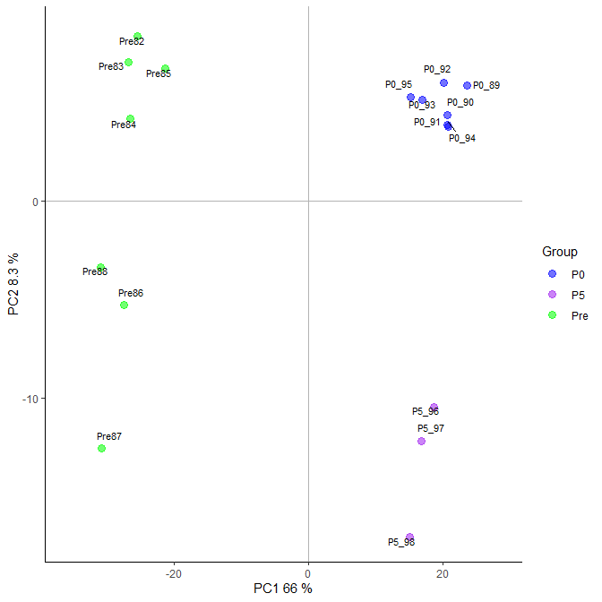

Anàlisis PCA de los datos filtrados

```r
> knitr::include_graphics("figuras/ResumQM_filt.png")
```

## Diseño matriz experimental

El siguiente paso en el estudio es la creación o diseño de la matriz experimental que se realiza con la función *designMat()* . La matriz resultante es una matriz de 1 y 0 donde el valor 1 quiere decir que esa muestra ( que las encontramos dispuestas en filas) corresponde a un determinado grupo ( dispuestos en las columnas).

```
       P0 P5 Pre
 Pre82  0  0   1
 Pre83  0  0   1
 Pre84  0  0   1
 Pre85  0  0   1
 Pre86  0  0   1
 Pre87  0  0   1
 Pre88  0  0   1
 P0_89  1  0   0
 P0_90  1  0   0
 P0_91  1  0   0
 P0_92  1  0   0
 P0_93  1  0   0
 P0_94  1  0   0
 P0_95  1  0   0
 P5_96  0  1   0
 P5_97  0  1   0
 P5_98  0  1   0
attr(,"assign")
[1] 1 1 1
attr(,"contrasts")
attr(,"contrasts")$Grupo
[1] "contr.treatment"
```

A continuación seguimos con la matriz de contrstes para la comparación 2 a 2 de los grupos creados

```
      Contrasts
Levels PP0 PP5 PP05
   P0   -1   0    1
   P5    0  -1   -1
   Pre   1   1    0
```

## Selección de genes diferencialmente expresados y anotación

Una vez ya tenemos definidas la matriz de diseño y la de contraste con el paquete *limma*podemos proceder a la selección de genes expresados diferencialmente y a su anotación.

```r
> fit<-lmFit(eset_filt, designMat)
> fit.main<-contrasts.fit(fit, cont.matrix)
> fit.main<-eBayes(fit.main)
> head(fit.main)
```

```
An object of class "MArrayLM"
$coefficients
           Contrasts
                   PP0        PP5        PP05
  151494_at -0.2070358 -0.4289567 -0.22192096
  153135_at -0.7667038 -0.8267176 -0.06001381
  154994_at -1.1560770 -1.3125978 -0.15652079
  152298_at -0.4667538 -0.6124326 -0.14567880
  143798_at  2.5541842  4.2764838  1.72229962
  152911_at  0.6639670  1.2701890  0.60622199

$rank
[1] 3

$assign
[1] 1 1 1

$qr
$qr
              P0        P5        Pre
 Pre82 -2.645751  0.000000  0.0000000
 Pre83  0.000000 -1.732051  0.0000000
 Pre84  0.000000  0.000000 -2.6457513
 Pre85  0.000000  0.000000  0.3779645
 Pre86  0.000000  0.000000  0.3779645
12 more rows ...

$qraux
[1] 1.000000 1.000000 1.377964

$pivot
[1] 1 2 3

$tol
[1] 1e-07

$rank
[1] 3


```

[output cut: 87 more lines]

```
           Contrasts
                  PP0       PP5      PP05
  151494_at -6.571029 -4.650923 -6.050125
  153135_at  4.631505  2.373579 -6.852933
  154994_at 11.859547  9.847255 -6.293435
  152298_at -2.787673 -2.475397 -6.568292
  143798_at 21.050642 25.911322 10.066153
  152911_at -4.962280 -2.152309 -5.407255

$F
[1]   3.566657  29.103067  75.210254   9.179426 320.129095   7.674547

$F.p.value
[1] 4.815750e-02 1.530920e-06 8.159783e-10 1.591277e-03 1.760035e-15
[6] 3.549307e-03
```

```r
> results <- decideTests(fit.main)
> summary(results)
```

```
        PP0  PP5 PP05
Down   1438 1268  271
NotSig  483  813 2401
Up      955  795  204
```

```r
> topTab_PP0 <- topTable(fit.main, number = nrow(fit.main),coef= 1, adjust="fdr")
>
> topTab_PP5 <- topTable(fit.main, number = nrow(fit.main),coef= 2, adjust="fdr")
>
> topTab_PP05 <- topTable(fit.main, number = nrow(fit.main), coef= 3, adjust="fdr")
>
> head(topTab_PP0)
```

```
              logFC  AveExpr         t      P.Value    adj.P.Val        B
149304_at -5.444965 6.630441 -57.94541 4.844901e-23 1.393394e-19 42.06919
152504_at  4.008227 8.217189  43.29650 1.258222e-20 1.740472e-17 37.18664
141361_at -4.403292 7.196863 -42.47019 1.815513e-20 1.740472e-17 36.84954
154473_at -4.858746 7.139983 -32.88628 2.320730e-18 1.668605e-15 32.25730
152515_at  2.606889 8.393754  32.07716 3.715300e-18 2.137041e-15 31.80061
143276_at  3.020383 9.775735  31.50812 5.208655e-18 2.496682e-15 31.47169
```

```r
> head(topTab_PP5)
```

```
              logFC  AveExpr         t      P.Value    adj.P.Val        B
149304_at -4.128635 6.630441 -34.03345 1.213530e-18 3.490112e-15 32.70173
152504_at  3.868532 8.217189  32.36849 3.132152e-18 4.504035e-15 31.81657
142351_at -3.778902 5.598634 -31.52377 5.160103e-18 4.946819e-15 31.34672
141361_at -4.139400 7.196863 -30.92572 7.405827e-18 5.324790e-15 31.00513
154473_at -5.018644 7.139983 -26.31192 1.542669e-16 8.873430e-14 28.08836
152515_at  2.622263 8.393754  24.99339 4.034041e-16 1.745033e-13 27.14989
```

```r
> head(topTab_PP05)
```

```
                logFC  AveExpr         t      P.Value    adj.P.Val        B
142351_at   -2.739460 5.598634 -22.85269 2.137331e-15 6.146964e-12 24.56302
149770_at    3.073472 8.040702  15.61446 2.242227e-12 3.224323e-09 18.39766
151630_at    1.707209 8.614367  13.63427 2.471620e-11 2.369460e-08 16.13605
145560_at    1.952235 6.952139  12.58030 9.998356e-11 7.188818e-08 14.79621
151727_s_at  1.840085 5.216161  11.85085 2.780847e-10 1.599543e-07 13.80648
141536_at    1.713911 8.574241  11.56053 4.235522e-10 2.030227e-07 13.39738
```

```
    PROBEID   SYMBOL ENTREZID                                       GENENAME
1 141200_at    Hmg-2    37407                  High mobility group protein 2
2 141204_at GCS2beta    35056                     Glucosidase 2 beta subunit
3 141205_at    Naa60    39142                  N(alpha)-acetyltransferase 60
4 141217_at     Dak1    43165                                           Dak1
5 141218_at   Hrb27C    33968 Heterogeneous nuclear ribonucleoprotein at 27C
6 141219_at   CG7099    34753                        uncharacterized protein
         logFC  AveExpr           t      P.Value    adj.P.Val          B
1 -0.433568424 5.309338 -4.55473219 2.109591e-04 3.891714e-04 -0.4666475
2 -0.009620201 6.409605 -0.06801962 9.464727e-01 9.487820e-01 -7.8490369
3 -0.495252140 6.075200 -3.61069618 1.835382e-03 2.767991e-03 -2.6269061
4  1.138547596 6.471827  9.46492205 1.141421e-08 8.969201e-08  9.6046441
5  0.511630924 3.104276  4.40141481 2.994030e-04 5.302235e-04 -0.8190249
6 -0.458122212 5.289664 -4.70309625 1.505203e-04 2.901450e-04 -0.1261150
```

```
    PROBEID   SYMBOL ENTREZID                                       GENENAME
1 141200_at    Hmg-2    37407                  High mobility group protein 2
2 141204_at GCS2beta    35056                     Glucosidase 2 beta subunit
3 141205_at    Naa60    39142                  N(alpha)-acetyltransferase 60
4 141217_at     Dak1    43165                                           Dak1
5 141218_at   Hrb27C    33968 Heterogeneous nuclear ribonucleoprotein at 27C
6 141219_at   CG7099    34753                        uncharacterized protein
        logFC  AveExpr           t   P.Value adj.P.Val         B
1 -0.02163003 5.309338 -0.17601029 0.8621273 0.9391963 -6.926620
2 -0.27251975 6.409605 -1.49253207 0.1517950 0.3555068 -5.844756
3  0.11005461 6.075200  0.62151049 0.5415669 0.7356988 -6.743438
4 -0.36302444 6.471827 -2.33763843 0.0303663 0.1240228 -4.439218
5  0.01102236 3.104276  0.07344896 0.9422080 0.9743941 -6.939942
6  0.05037758 5.289664  0.40060418 0.6931302 0.8437494 -6.859458
```

```
    PROBEID   SYMBOL ENTREZID                                       GENENAME
1 141200_at    Hmg-2    37407                  High mobility group protein 2
2 141204_at GCS2beta    35056                     Glucosidase 2 beta subunit
3 141205_at    Naa60    39142                  N(alpha)-acetyltransferase 60
4 141217_at     Dak1    43165                                           Dak1
5 141218_at   Hrb27C    33968 Heterogeneous nuclear ribonucleoprotein at 27C
6 141219_at   CG7099    34753                        uncharacterized protein
       logFC  AveExpr         t      P.Value    adj.P.Val          B
1 -0.4551985 5.309338 -3.704091 1.482168e-03 0.0032220077 -2.2339595
2 -0.2821400 6.409605 -1.545220 1.386016e-01 0.1705812137 -6.4838646
3 -0.3851975 6.075200 -2.175323 4.228584e-02 0.0580219769 -5.4451720
4  0.7755232 6.471827  4.993859 7.802709e-05 0.0002804452  0.7163636
5  0.5226533 3.104276  3.482770 2.457768e-03 0.0049351896 -2.7325050
6 -0.4077446 5.289664 -3.242399 4.239304e-03 0.0077900726 -3.2658975
```

# RESULTADOS Y DISCUSIÓN

## Visualización de la expresión diferencial

```r
> geneSymbols <- select(drosgenome1.db, rownames(fit.main), c("SYMBOL"))
> SYMBOLS <- geneSymbols$SYMBOL
```

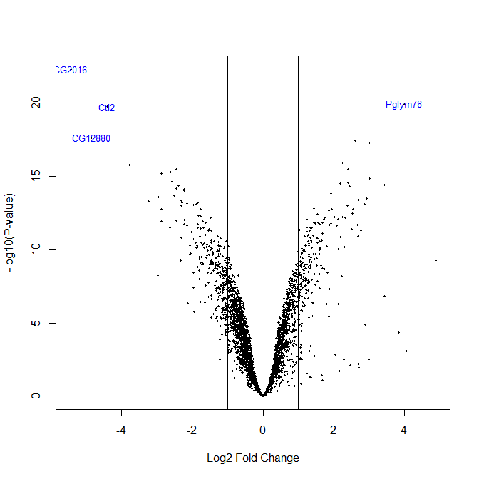

Genes expresados diferencialmente para PP0

```r
> volcanoplot(fit.main, coef = 1, highlight = 4, names = SYMBOLS)
> abline(v=c(-1,1))
```

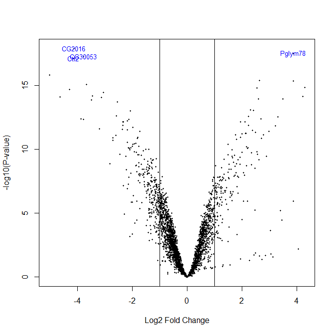

Genes expresados diferencialmente para PP5

```r
> volcanoplot(fit.main, coef = 2, highlight = 4, names = SYMBOLS)
> abline(v=c(-1,1))
```

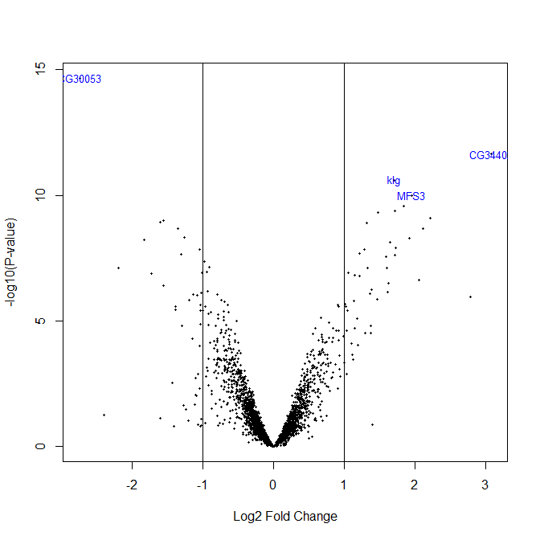

Genes expresados diferencialmente para P05

```r
> volcanoplot(fit.main, coef = 3, highlight = 4, names = SYMBOLS)
> abline(v=c(-1,1))
```

## Comparaciónes multiples y visualización

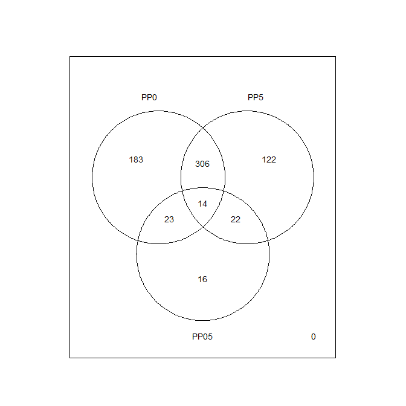

Diagrama de Venn de los genes en común

Los heatmaps son otra forma de visualizar estas comparaciones . En este tipo de gráficos se utiliza una paleta de colores para diferenciar los niveles de expresión.

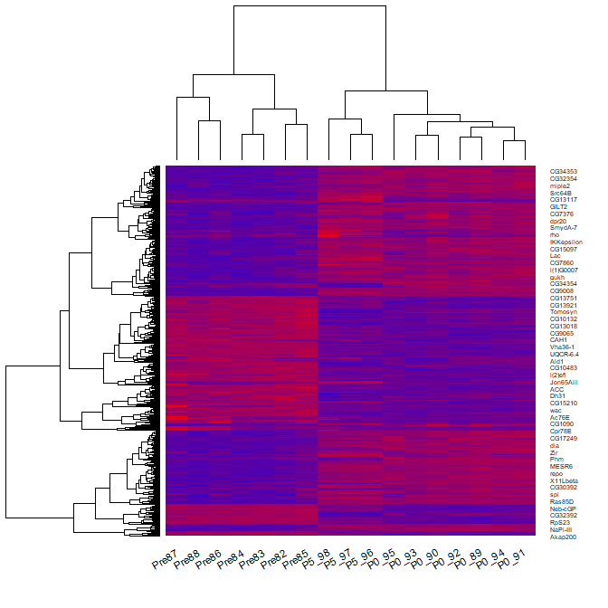

Genes expresados diferencialmente

## Significación biológica

```
 PP0  PP5 PP05
2565 2310  766
```

```r
> listOfData <- listOfSelected[1:3]
> comparisonsNames <- names(listOfData)
> universe <- mapped_genes
> for (i in 1:length(listOfData)) {
+   genesIn <- listOfData[[i]]
+   comparison <- comparisonsNames[i]
+   enrich.result <- enrichPathway(gene = genesIn,
+                                  pvalueCutoff = 0.05,
+                                  readable = T,
+                                  pAdjustMethod = "BH",
+                                  organism = "fly",
+                                  universe = universe)
+
+  }
> print(genesIn)
> print(genesIn[1001:2310])
> print(genesIn[2001:2310])
> str(genesIn)
> #write.csv2(as.data.frame(enrich.result), file.path("./results/enrich_results.cvs"))
> #comparison<- comparisonsNames[1]
> #cnetplot(enrich.result, categorySize="geneNum", showCategory = 3,vertex.label.cex = 0.2)
```

Debido a errores en la función de “Gene Enrichment Analysis” se ha realizado el estudio de significación biologica con la herremienta g:Profiler y estos han sido los resultados:

[figure not shown]

[figure not shown]

## Resumen de resultados

```r
> Result_Files <- dir("./results/")
> knitr::kable(
+   Result_Files, booktabs = TRUE,
+   caption = "Listado de ficheros de resultados",
+   col.names="Ficheros"
+ )
```

Listado de ficheros de resultados

| Ficheros |
| --- |
| Annotated_P05.csv |
| Annotated_PP0.csv |
| Annotated_PP5.csv |
| datos_norm.csv |
| enrich_results.cvs |
| gprofiler_dmelanogaster.ENSG.zip |
| gprofiler_dmelanogaster.name.zip |
| heatmap.csv |
| Norm_data_filt |
| Norm_data_filt.csv |
| rawData_quality |
| rawDataNorm_quality |

# APENDICE

```r
> library(knitr)
> knitr::opts_chunk$set(echo = TRUE, message = FALSE, warning = FALSE,
+                       comment = NA, prompt = TRUE, tidy = FALSE,
+                       fig.width = 7, fig.height = 7, fig_caption = TRUE,
+                       cache=FALSE)
>
> setwd(".")
> dir.create("data")
> dir.create("results")
> dir.create("figuras")
>
> library(ggplot2)
> library(ggrepel)
> library(oligo)
> library(Biobase)
> library(GEOquery)
> library(arrayQualityMetrics)
> library(pvca)
> library(genefilter)
> library(limma)
> library(gplots)
> library(ReactomePA)
> library(BiocGenerics)
> library(BiocParallel)
> library(BiocManager)
> library(tinytex)
> library(genefilter)
>
> targets <- read.csv2("./data/targets.csv", header = TRUE, sep = ",")
> knitr::kable(
+   targets, booktabs = TRUE,
+   caption = 'Contenido del fichero *targets.csv* ')
> celFiles <- list.celfiles("./data", full.names = TRUE)
>
> my.targets <-read.AnnotatedDataFrame(file.path("./data","targets.csv"),
+                                       header = TRUE, row.names = 1,
+                                       sep=",")
> rawData <- read.celfiles(celFiles, phenoData = my.targets)
>
> my.targets@data$ShortName->rownames(pData(rawData))
>
> colnames(rawData)<-rownames(pData(rawData))
>
> head(rawData)
>
> arrayQualityMetrics(rawData, outdir = file.path("./results","rawData_quality"), force = T)
> knitr::include_graphics("figuras/ResumQM.png")
> labels <- c("Pre","P0","P5")
>
> boxplot(rawData, cex.axis = 0.5, las=2, which="all", main="Boxplot de valores de intensidad",
+         col = c(rep("blue", 7), rep("purple", 7), rep("green", 3)))
> legend("topleft", labels,fill= c("blue","purple","green"), bty="n")
> plot(hclust(dist(t(exprs(rawData)))))
> plotPCA <- function(datos, labels, factor, scale,
+                     colores, size = 1.5, glineas = 0.25) {
+   data <- prcomp(t(datos), scale = scale)
+   #plot adjustments
+   dataDF <- data.frame(data$x)
+   Group <- factor
+   loads <- round(data$sdev^2/sum(data$sdev^2)*100, 1)
+   #main plot
+   p1 <- ggplot(dataDF, aes(x=PC1, y =PC2)) +
+     theme_classic() +
+     geom_hline(yintercept = 0, color = "gray70") +
+     geom_vline(xintercept = 0, color = "gray70") +
+     geom_point(aes(color = Group), alpha = 0.55, size = 3) +
+     coord_cartesian(xlim = c(min(data$x[,1])-5, max(data$x[,1])+5)) +
+     scale_fill_discrete(name = "Group")
+   #avoiding labels superposition
+   p1 + geom_text_repel(aes(y = PC2 + 0.25, label = labels), segment.size = 0.25, size = size) +
+     labs(x = c(paste("PC1", loads[1], "%")), y = c(paste("PC2", loads[2], "%"))) +
+     theme(plot.title = element_text(hjust = 0.5)) +
+     scale_colour_manual(values = colores)
+ }
> plotPCA(exprs(rawData), labels = targets$ShortName, factor = targets$Grupo,
+         scale = F, size = 3, colores = c("blue","purple","green"))
> eset_rma<- rma(rawData)
> eset_rma
> write.csv2(exprs(eset_rma), file = "./results/datos_norm.csv")
> arrayQualityMetrics(eset_rma, outdir = file.path("./results", "rawDataNorm_quality"), force = T)
> knitr::include_graphics("figuras/ResumQM_norm.png")
>
> labels <- c("Pre","P0","P5")
>
> boxplot(eset_rma, cex.axis = 0.5, las=2, which="all", main="Boxplot de valores de intensidad datos normalizados",
+         col = c(rep("blue", 7), rep("purple", 7), rep("green", 3)))
> legend("topleft", labels,fill= c("blue","purple","green"), bty="n")
>
>
>
> plot(hclust(dist(t(exprs(eset_rma)))))
>
>
>
> plotPCA(exprs(eset_rma), labels = targets$ShortName, factor = targets$Grupo,
+         scale = F, size = 3, colores = c("blue","purple","green"))
>
>
>
>
> ## Selección de genes
>
> sds <- apply(exprs(eset_rma), 1, sd)
> sds0 <- sort(sds)
> plot(1:length(sds0), sds0, xlab="Genes desde el menos al más variable", ylab="Desviación estándar")
> abline(v=length(sds)*c(0.9,0.95))
>
>
> ## Anotaciones
>
>
>
>
> library(drosgenome1.db)
> annotation(eset_rma)<-"drosgenome1.db"
>
>
>
> ## Filtraje de genes
>
>
>
>
> filtered <- nsFilter(eset_rma,require.entrez = TRUE, remove.dupEntrez = TRUE,
+                      var.filter = TRUE, var.func = IQR, var.cutoff = 0.75,
+                      filterByQuantile = T, feature.exclude = "^AFFX")
>
> print(filtered$filter.log)
> eset_filt<- filtered$eset
> write.csv2(exprs(eset_filt), file="./results/Norm_data_filt.csv")
>
>
> ## Control de calidad dato filtrados
>
> arrayQualityMetrics(eset_filt, outdir = file.path("./results", "Norm_data_filt"), force= T)
>
> knitr::include_graphics("figuras/ResumQM_filt.png")
>
> labels <- c("Pre","P0","P5")
>
> boxplot(eset_filt, cex.axis = 0.5, las=2, which="all", main="Boxplot de valores de intensidad datos filtrados",
+         col = c(rep("blue", 7), rep("purple", 7), rep("green", 3)))
> legend("topleft", labels,fill= c("blue","purple","green","yellow"), bty="n")
>
> plot(hclust(dist(t(exprs(eset_filt)))))
>
> plotPCA(exprs(eset_filt), labels = targets$ShortName, factor = targets$Grupo,
+         scale = F, size = 3, colores = c("blue","purple","green"))
>
> ## Diseño matriz experimental
>
> designMat<- model.matrix(~0+Grupo, pData(eset_filt))
>
> colnames(designMat) <- c("P0","P5","Pre")
> print(designMat)
>
> cont.matrix<- makeContrasts(PP0= Pre-P0, PP5= Pre-P5, PP05=P0-P5, levels = designMat)
> cont.matrix
>
> ## Selección de genes diferencialmente expresados y anotación
>
> fit<-lmFit(eset_filt, designMat)
> fit.main<-contrasts.fit(fit, cont.matrix)
> fit.main<-eBayes(fit.main)
> head(fit.main)
> results <- decideTests(fit.main)
> summary(results)
>
> topTab_PP0 <- topTable(fit.main, number = nrow(fit.main),coef= 1, adjust="fdr")
>
> topTab_PP5 <- topTable(fit.main, number = nrow(fit.main),coef= 2, adjust="fdr")
>
> topTab_PP05 <- topTable(fit.main, number = nrow(fit.main), coef= 3, adjust="fdr")
>
> head(topTab_PP0)
> head(topTab_PP5)
> head(topTab_PP05)
>
> annotatedTopTable <- function(topTab, anotPackage)
+ {
+   topTab <- cbind(PROBEID=rownames(topTab), topTab)
+   myProbes <- rownames(topTab)
+   thePackage <- eval(parse(text = anotPackage))
+   geneAnots <- select(thePackage, myProbes, c("SYMBOL", "ENTREZID", "GENENAME"))
+   annotatedTopTab <- merge(x=geneAnots, y=topTab, by.x="PROBEID", by.y="PROBEID")
+   return(annotatedTopTab)
+ }
>
> topAnnotated_PP0 <- annotatedTopTable(topTab_PP0,
+                                             anotPackage = "drosgenome1.db")
> topAnnotated_PP5 <- annotatedTopTable(topTab_PP5,
+                                               anotPackage = "drosgenome1.db")
> topAnnotated_P05 <- annotatedTopTable(topTab_PP05,
+                                       anotPackage = "drosgenome1.db")
> head(topAnnotated_PP0)
> head(topAnnotated_P05)
> head(topAnnotated_PP5)
>
> write.csv(topAnnotated_PP0, file="./results/Annotated_PP0.csv")
> write.csv(topAnnotated_PP5, file="./results/Annotated_PP5.csv")
> write.csv(topAnnotated_P05, file="./results/Annotated_P05.csv")
>
>
> # RESULTADOS
>
> ## Visualización de la expresión diferencial
>
> geneSymbols <- select(drosgenome1.db, rownames(fit.main), c("SYMBOL"))
> SYMBOLS <- geneSymbols$SYMBOL
>
> volcanoplot(fit.main, coef = 1, highlight = 4, names = SYMBOLS)
> abline(v=c(-1,1))
>
>
>
> volcanoplot(fit.main, coef = 2, highlight = 4, names = SYMBOLS)
> abline(v=c(-1,1))
>
>
> volcanoplot(fit.main, coef = 3, highlight = 4, names = SYMBOLS)
> abline(v=c(-1,1))
>
> ## Comparaciónes multiples y visualización
>
>
> res <- decideTests(fit.main, method = "separate", adjust.method = "fdr", p.value = 0.1, lfc = 1)
> sum.res.rows <- apply(abs(res),1,sum)
> res.selected <- res[sum.res.rows!=0,]
> print(summary(res))
>
>
> vennDiagram(res.selected[, 1:3], cex = 0.9)
>
> probesInHeatmap <- rownames(res.selected)
> HMdata <- exprs(eset_filt)[rownames(exprs(eset_filt)) %in% probesInHeatmap,]
> geneSymbols <- select(drosgenome1.db, rownames(HMdata), c("SYMBOL"))
> SYMBOLS <- geneSymbols$SYMBOL
> rownames(HMdata) <- SYMBOLS
> my_palette <- colorRampPalette(c("blue", "red"))(n =299)
> write.csv2(HMdata, file=file.path("./results/heatmap.csv"))
>
>
> heatmap.2(HMdata, Rowv = T, Colv = T,
+           scale = "row", col = my_palette, sepcolor = "white",
+           sepwidth = c(0.05,0.05), cexRow = 0.5, cexCol = 0.9,
+           key = F, density.info = "histogram",
+           tracecol = NULL, dendrogram = "both", srtCol = 30)
>
> ## Significación biológica
>
>
> listOfTables <- list(PP0 = topTab_PP0,
+                      PP5 = topTab_PP5,
+                      PP05 = topTab_PP05)
> listOfSelected <- list()
> for(i in 1:length(listOfTables)){
+   topTab <- listOfTables[[i]]
+   whichGenes <- topTab["adj.P.Val"]<0.15
+   selectedIDs <- rownames(topTab)[whichGenes]
+   EntrezIDs <- select(drosgenome1.db, selectedIDs, c("ENTREZID"))
+   EntrezIDs <- EntrezIDs$ENTREZID
+   listOfSelected[[i]] <- EntrezIDs
+   names(listOfSelected)[i] <- names(listOfTables)[i]
+ }
> sapply(listOfSelected, length)
>
>
> library(org.Hs.eg.db)
> mapped_genes2GO <- mappedkeys(org.Hs.egGO)
> mapped_genes2KEGG <- mappedkeys(org.Hs.egPATH)
> mapped_genes <- union(mapped_genes2GO, mapped_genes2KEGG)
```

# REFERENCIAS

Gonzalo Sanz, Ricardo, and Alex Sánchez-Pla. 2019. “Statistical Analysis of Microarray Data.” In *Microarray Bioinformatics*, edited by Verónica Bolón-Canedo and Amparo Alonso-Betanzos, 87–121. New York, NY: Springer New York. https://doi.org/10.1007/978-1-4939-9442-7_5.

Hoopfer ED, Watts RJ, Penton A. n.d. “Genomic Analysis of Drosophila Neuronal Remodeling: A Role for the Rna-Binding Protein Boule as a Negative Regulator of Axon Pruning.” *J Neurosci* 28(24)::6092–103.

Irizarry, B, R. A.; Hobbs. 2003. “Exploration, Normalization, and Summaries of High Density Oligonucleotide Array Probe Level Data.” *Biostatistics* 4 (2): 249–64. https://doi.org/10.1093/biostatistics/4.2.249.

[^1]: https://cran.r-project.org/index.html
[^2]: https://www.rstudio.com/
[^3]: https://www.bioconductor.org/
[^4]: https://biit.cs.ut.ee/gprofiler/gost
[^5]: https://www.ncbi.nlm.nih.gov/geo/geo2r/?acc=GSE10012